# Foundations of the Grammar of Graphics

## Coordinates

- Overview
- Zoom (coord)
- Output 1
- Drop (scale)
- Output 2
- what kind of canvas should the final data be drawn on?
  - i.e., how should x and y be interpreted
- Limits and transformation can be applied in scale or in coord
  - scale will apply it in the beginning (`NA` values), [i.e., changing limits of a scale is not always the same as visually zooming in to a region of the plot](https://ggplot2-book.org/scales-position#sec-zooming-in)
  - [coord will apply it in the end (“zoom in”)](https://ggplot2.tidyverse.org/reference/coord_cartesian.html)
  - `coord_polar()`: polar coordinate system interprets x and y as radius and angle

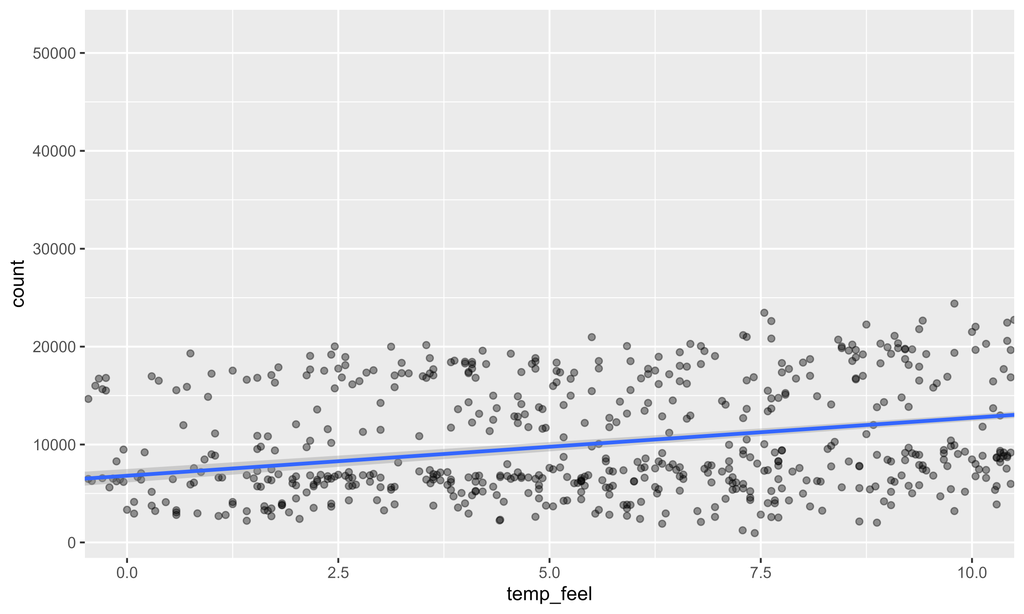

```r
# coord_cartesian zooms in — smooth is fitted on ALL data
ggplot(bikes, aes(x = temp_feel, y = count)) +
  geom_point(alpha = 0.4) +
  geom_smooth(method = "lm") +
  coord_cartesian(xlim = c(0, 10))
```

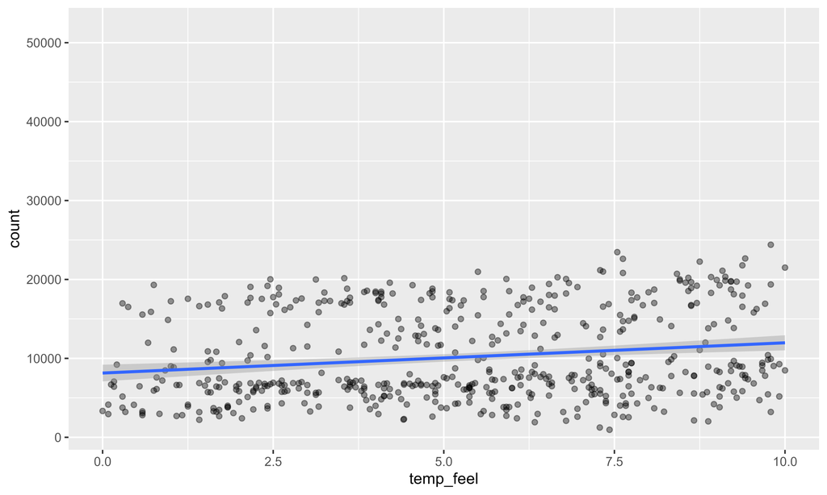

```r
# scale limits drop warm-day data before the smooth is computed
# → smooth only sees cold days, misses the peak: different trajectory
# ⚠️ ggplot2 warns: "N rows containing non-finite values removed"
ggplot(bikes, aes(x = temp_feel, y = count)) +
  geom_point(alpha = 0.4) +
  geom_smooth(method = "lm") +
  scale_x_continuous(limits = c(0, 10))
```

## Recent changes

Changes from ggplot2 3.4–3.5:

**Lines use `linewidth`, not `size`** (ggplot2 3.4.0, Nov 2022)

```r
# deprecated — warns in current ggplot2:
geom_line(size = 1.2)
# current:
geom_line(linewidth = 1.2)
```

**Inside-legend placement requires two arguments** (ggplot2 3.5.0, Feb 2024)

```r
# silently broken since 3.5.0:
theme(legend.position = c(0.8, 0.9))
# current:
theme(legend.position = "inside",
      legend.position.inside = c(0.8, 0.9))
```

**Guide styling via `theme()`, not guide functions** (ggplot2 3.5.0)

```r
# soft-deprecated:
guides(fill = guide_colorbar(frame.colour = "black"))
# current:
theme(legend.frame = element_rect(colour = "black"))
```

# Application 1

## Application 1

**Work through the `02_foundations_exercises.qmd` together with your neighbor, running the code yourself and trying to understand the syntax behind the Grammar of Graphics.**

➡️ For each of the chart types involved (e.g. bar chart, scatter plot, etc.) consult the excellent book [Fundamentals of Data Visualisation](https://clauswilke.com/dataviz/) by Claus Wilke to develop an intuition of good and bad practices of each type of chart.

➡️ You may also want to consult the book’s [source code](https://github.com/clauswilke/dataviz) to check out the code behind the best practice examples.

`45:00`

# Application 2

## Application 2

**Work through the `02_applied_gles.qmd`, trying to understand not only the syntax behind the Grammar of Graphics, but also the data transformations needed before plotting.**

➡️ What other interesting variables could be visualized in terms of their distribution (overall and across groups of respondents)?

➡️ Try to adapt the code to visualize other variables of interest, including their means and confidence intervals.

`45:00`

# Application 3

## Application 3

**Rely on some data that is relevant to your field and subject of your PhD. Try to visualize some of the data using the Grammar of Graphics `ggplot2` framework. You may want to consider visualizing distributions, proportions, associations, and uncertainty.**

🤓 Try to incorporate the [“Principle of Proportional Ink”](https://clauswilke.com/dataviz/proportional-ink.html) into your visualizations.

➡️ If you feel unsure about a potential dataset to look at, explore the bike sharing data set introduced earlier and challenge yourself by completing [Exercise 2](https://github.com/posit-conf-2023/dataviz-ggplot2/blob/main/materials/exercises/01-fundamentals-exercises.qmd).

`60:00`

# Questions? 🙋 🙋‍♂️

# Thanks for your attention.

## References

[figure not shown]

Wickham, Hadley. 2010. “A Layered Grammar of Graphics.” *Journal of Computational and Graphical Statistics* 19 (1): 3–28.

Wickham, Hadley, Mine Çetinkaya-Rundel, and Garrett Grolemund. 2023. *R for Data Science*. " O’Reilly Media, Inc.".

Wilkinson, Leland. 2012. *The Grammar of Graphics*. Springer.